# 効果の異質性

事例の集計

川田恵介

# 条件付き平均差

- $$\tau_P(X)=E_P[Y|D=1,X]-E_P[Y|D=0,X]$$
  の予測モデル
  $$g_{\tau}(X)$$
  を推定
  - どのような層において、差が大きいのか?

## 応用: 医療行為の”個人化”

- 医療行為における既存の統計分析は、平均的な効果に焦点を当てる
  - 有効な医療行為は、個人の体質等に依存している可能性
  - 個人に合わせた医療行為を、“根拠”を持って、行いたい

## 応用: マンション経営コンサルテーション

- 中古マンションの”リノベ”コンサルサービスを展開したい
  - 改築を行えば、どの程度市場価値が上がるのか?
  - 根拠を持って、“予測”したい

# 一般化された部分線形モデル

- $$E[Y|D,X]=\tau(X)\times D+f(X)$$
- 前回は
  $$\tau(X)=\tau$$

## R Learner

- 大本のアイディアを示した研究者 (Robinson) にちなんで
1. $Y,D$ の予測モデル $g_Y(X),g_D(X)$ を推定
2. $D$ についての予測誤差 $D-g_D(X)$ から、 $Y$ についての予測誤差 $Y-g_Y(X)$ を予測するモデルを機械学習を用いて、推定
- 前回は、単回帰

## Causal Forest

- 最も代表的な方法
- 以下を最小にするように”深い”決定木を推定
  $$E[(Y-g_Y(X)-\tau(X)\times [D-g_D(X))]^2]$$
  - 大量の決定木を推定し、平均を予測値とする

## 例 Causal Forest

```r
Fit <- causal_forest(
  X = X,
  Y = Y,
  W = D,
  Y.hat = FitY$SL.predict,
  W.hat = FitD$SL.predict
  )
```

## 例

```
GRF tree object
Number of training samples: 2086
Variable splits:
(1) split_variable: Tenure  split_value: 19
  (2) split_variable: Size  split_value: 80
    (4) split_variable: DistanceStation  split_value: 4
      (8) split_variable: Size  split_value: 50
        (14) split_variable: Tenure  split_value: 15
          (24) split_variable: Tenure  split_value: 3
            (34) * num_samples: 12  avg_Y: 42 avg_W: 0.08
            (35) split_variable: After  split_value: 0
              (48) split_variable: Tenure  split_value: 8
                (58) * num_samples: 23  avg_Y: 33.61 avg_W: 0.04
                (59) split_variable: Size  split_value: 25
                  (70) split_variable: Youseki  split_value: 500
                    (78) * num_samples: 10  avg_Y: 21.2 avg_W: 0
                    (79) * num_samples: 4  avg_Y: 26.25 avg_W: 0.25
                  (71) * num_samples: 14  avg_Y: 42.29 avg_W: 0.14
              (49) * num_samples: 58  avg_Y: 32.55 avg_W: 0.17
          (25) split_variable: Size  split_value: 20
            (36) * num_samples: 27  avg_Y: 23.15 avg_W: 0.19
            (37) * num_samples: 13  avg_Y: 35.69 avg_W: 0.23
        (15) * num_samples: 62  avg_Y: 67.06 avg_W: 0.21
      (9) split_variable: Tenure  split_value: 13
        (16) split_variable: Size  split_value: 50
          (26) split_variable: RoomD  split_value: 0
            (38) split_variable: ZoneHouse  split_value: 0
              (50) split_variable: Kenpei  split_value: 60
                (60) * num_samples: 38  avg_Y: 23 avg_W: 0.16
                (61) * num_samples: 55  avg_Y: 26.44 avg_W: 0.05
              (51) * num_samples: 23  avg_Y: 24.7 avg_W: 0.09
            (39) * num_samples: 64  avg_Y: 45.69 avg_W: 0.14
          (27) split_variable: After  split_value: 0
            (40) * num_samples: 48  avg_Y: 59.56 avg_W: 0.1
            (41) * num_samples: 48  avg_Y: 67.92 avg_W: 0.1
        (17) split_variable: RoomNum  split_value: 1
          (28) split_variable: Tenure  split_value: 17
            (42) * num_samples: 45  avg_Y: 29.2 avg_W: 0.24
            (43) * num_samples: 18  avg_Y: 29.22 avg_W: 0.28
          (29) split_variable: Youseki  split_value: 300
```

[output cut: 29 more lines]

```
                (65) * num_samples: 11  avg_Y: 54.91 avg_W: 0.64
            (47) split_variable: DistanceStation  split_value: 4
              (56) split_variable: Youseki  split_value: 400
                (66) * num_samples: 17  avg_Y: 32.47 avg_W: 0.29
                (67) * num_samples: 14  avg_Y: 33.5 avg_W: 0.5
              (57) split_variable: After  split_value: 0
                (68) split_variable: Size  split_value: 50
                  (74) * num_samples: 19  avg_Y: 23.29 avg_W: 0.58
                  (75) * num_samples: 11  avg_Y: 41.64 avg_W: 0.64
                (69) split_variable: StructureSRC  split_value: 0
                  (76) * num_samples: 17  avg_Y: 34.42 avg_W: 0.59
                  (77) * num_samples: 22  avg_Y: 39.52 avg_W: 0.59
          (33) * num_samples: 46  avg_Y: 37.59 avg_W: 0.48
        (23) * num_samples: 11  avg_Y: 61.09 avg_W: 0.55
      (13) * num_samples: 23  avg_Y: 31.67 avg_W: 0.57
```

## 例

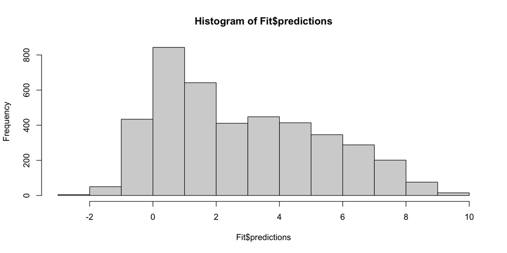

## 例

```r
predict(
  Fit,
  X[1,],
  estimate.variance = TRUE
  )
```

```
  predictions variance.estimates
1    4.595064           1.292561
```

## 例

```r
predict(
  Fit,
  X[10,],
  estimate.variance = TRUE
  )
```

```
  predictions variance.estimates
1    1.258022           1.008092
```

## 中間まとめ

- $X$ から $E_P[Y|D=1,X]-E_P[Y|D=0,X]$ を予測することは、（一応)可能
  - Random Forestであれば、 $X$ の数が少なければ、信頼区間も計算できる
- ただし多くの応用で、精度は高くない

# Best Linear Projection

- 線形近似であれば、より高い精度で推定できる
- $$\tau(X)\sim \beta_0 +..+\beta_LX_L$$

## 例: Best Linear Predictor

```
Best linear projection of the conditional average treatment effect.
Confidence intervals are cluster- and heteroskedasticity-robust (HC3):

                  Estimate Std. Error t value Pr(>|t|)
(Intercept)     -6.2073338 16.9261928 -0.3667 0.713840
Tenure           0.1620135  0.0581997  2.7838 0.005398 **
DistanceStation  0.0064317  0.1653409  0.0389 0.968972
Size             0.0269047  0.1648422  0.1632 0.870358
Youseki          0.0013010  0.0064271  0.2024 0.839599
Kenpei           0.0680964  0.2510171  0.2713 0.786188
RoomNum         -0.8088838  1.9941185 -0.4056 0.685032
ZoneHouse       -2.9130417  1.7496539 -1.6649 0.096004 .
ZoneBusiness    -1.8409048  5.1074760 -0.3604 0.718542
RoomL            1.1629912  2.8789665  0.4040 0.686262
RoomD            2.7253890  2.2822163  1.1942 0.232474
StructureSRC     0.4548949  1.5581650  0.2919 0.770345
After           -0.4104551  1.1855385 -0.3462 0.729196
---
Signif. codes:  0 '***' 0.001 '**' 0.01 '*' 0.05 '.' 0.1 ' ' 1
```

## 定数項の解釈

- 線形近似モデルの定数項は、通常解釈困難
- $$E[\tau|X]\simeq\underbrace{\beta_0}_{?} + .. + \beta_LX_L$$
- まっすぐな解釈は、 $E[\tau|X=0]=\beta_0$
  - 多くのデータで、$X=0$ の付近には事例がない
  - 近似の際に”無視”されている

## 例

[figure not shown]

## 中心化

- 元の変数を平均0に変換
- $$Z=X-E[X]$$
- 発展: 標準化
- $$Z=\frac{X-E[X]}{SD[X]}$$

## 例: Best Linear Predictor

```
Best linear projection of the conditional average treatment effect.
Confidence intervals are cluster- and heteroskedasticity-robust (HC3):

                  Estimate Std. Error t value  Pr(>|t|)
(Intercept)      2.3734583  0.6441662  3.6845 0.0002321 ***
Tenure           0.1620135  0.0581997  2.7838 0.0053980 **
DistanceStation  0.0064317  0.1653409  0.0389 0.9689722
Size             0.0269047  0.1648422  0.1632 0.8703575
Youseki          0.0013010  0.0064271  0.2024 0.8395991
Kenpei           0.0680964  0.2510171  0.2713 0.7861878
RoomNum         -0.8088838  1.9941185 -0.4056 0.6850321
ZoneHouse       -2.9130417  1.7496539 -1.6649 0.0960039 .
ZoneBusiness    -1.8409048  5.1074760 -0.3604 0.7185416
RoomL            1.1629912  2.8789665  0.4040 0.6862621
RoomD            2.7253890  2.2822163  1.1942 0.2324743
StructureSRC     0.4548949  1.5581650  0.2919 0.7703451
After           -0.4104551  1.1855385 -0.3462 0.7291964
---
Signif. codes:  0 '***' 0.001 '**' 0.01 '*' 0.05 '.' 0.1 ' ' 1
```

## 補論: 信頼区間の計算

- 多くの関数において、推定誤差(Std.Error)は報告される
- 95%信頼区間はざっくり
- $$推定値 \pm 2*Std.Error$$

## まとめ

- 機械学習は、条件付き平均差をそのまま推定するための活路
  - ただ依然として困難が多い
- 母集団における平均差を推測するツールの方が、現状より確立されている
  - 典型的な方法は、線形近似モデルの推定
  - 定式化に注意